# Let's learn about centralities!

## Picking the right Dolphins

Answer the following questions:

```python
#computing centrality measures for the Dolphin network and adding node attributes with values

def add_attributes_node(dolGraph, values, attribute):
  for node, val in values.items():
    dolGraph.nodes[node][attribute] = val
```

```python
def getcentrality(dolGraph, func):
  return func(dolGraph)
```

```python
def finishGraph(dolGraph, func, name):
  centrality = getcentrality(dolGraph, func)
  add_attributes_node(dolGraph, centrality, name)
```

```python
finishings = {
    "degree": nx.degree_centrality,
    "eigenvector": nx.eigenvector_centrality,
    "closeness": nx.closeness_centrality,
    "harmonic": nx.harmonic_centrality,
    "betweenness": nx.betweenness_centrality,
    "katz": nx.katz_centrality
}
```

```python
for name, function in finishings.items():
  print("Finishing graph nodes with centrality measure:", name)
  finishGraph(dolphin_social_network, function, name)
```

```
Finishing graph nodes with centrality measure: degree
Finishing graph nodes with centrality measure: eigenvector
Finishing graph nodes with centrality measure: closeness
Finishing graph nodes with centrality measure: harmonic
Finishing graph nodes with centrality measure: betweenness
Finishing graph nodes with centrality measure: katz
```

```python
dolphin_social_network.nodes['Beak']
```

```
{'betweenness': 0.01908259621374376,
 'closeness': 0.3465909090909091,
 'degree': 0.09836065573770492,
 'eigenvector': 0.1285035191108721,
 'harmonic': 25.983333333333324,
 'katz': 0.1352761473111646}
```

```python
nx.write_gexf(dolphin_social_network, "dolphin_centrality.gexf")
```

### 1) **Popularity contest**

We want to know who the top dolphins are in the network, the real centers of attraction. Using what you learned about centrality from the readings and videos, choose an appropriate centrality measure that will tell us who those dolphins are. Justify your decision and list who the important dolphins are

## Answer

So, we want to show popularity here. I considered the centrality measures which shows the number of connections/ how strongly connected a node is. This can be achieved by centrality measures that are based on *degree*. I used eigenvector centrality here to show the top dolphins in the "entire network".

**Eigenvector centrality**

# *Top Popular Dolphins* :

(highlighted in purple in the network below)

- Scabs
- SN4
- Topless
- Grin

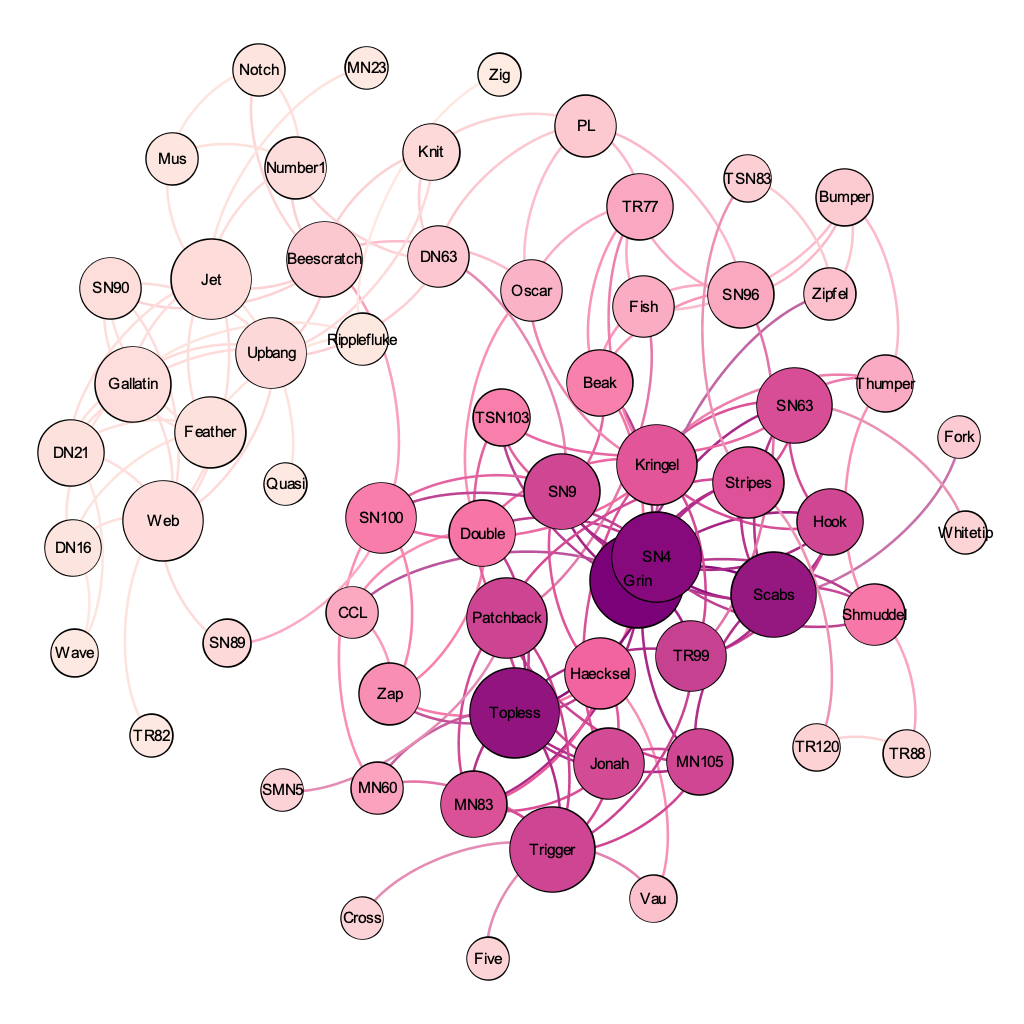

#### (2) **Relay**

Dolphins like passing information around efficiently along the shortest-paths. Among their neighbors who are the most important message relayers in the network? Justify your centrality choice for finding these dolphins.

## Answer

We need to find the nodes with access to the shortest paths in the network here. The nodes with most amount of shortest paths accessible to them would be most influential in relaying information most quickly in the network. I used closeness centrality measure here therefore.

**Closeness centrality**

# *Top Important Dolphins* :

(highlighted in purple in the network below)

- Kringel
- SN100
- SN4
- SN9

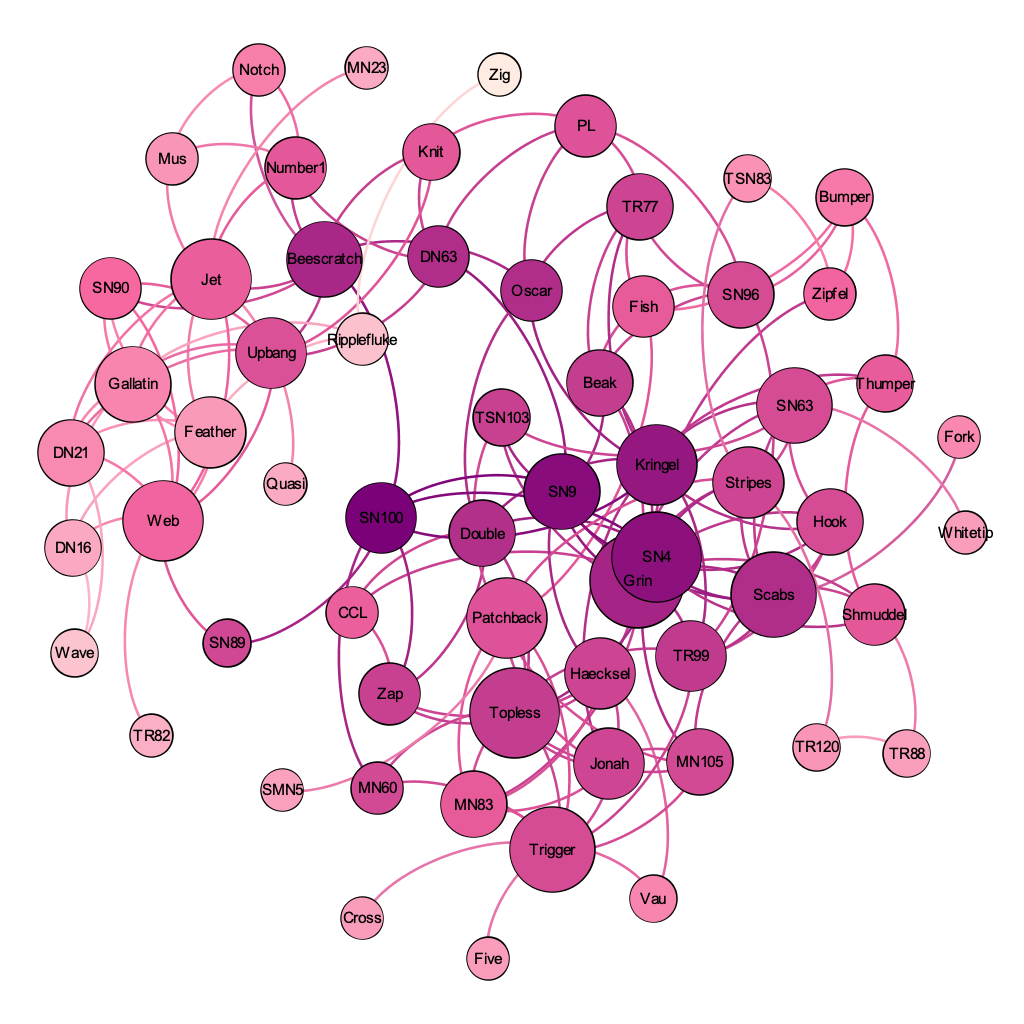

#### (3)**Gossip**

There is a lot smack going around the pod and everyone wants to know if Flipper will be inviting them to the party next week. But gossip takes time travel. Which dolphins are in the best position for getting all the best gossip from around the pod? Justify your centrality choice for finding these dolphins.

## Answer

To pass around the most amount of information requires people to have a certain kind of connections. It is not necessary to have the most amount of connections but it is about having a kind of connectivity that fills gaps and allows flow of information between various connections in their network. I therefore think betweenness centrality would be an appropriate measure to answer this question.

**Betweenness centrality**

# *Best positioned Dolphins* :

(highlighted in purple in the network below)

- Beescratch
- SN100

# *Slightly less important Dolphins* :

(highlighted in dark pink in the network below)

- SN4
- SN9

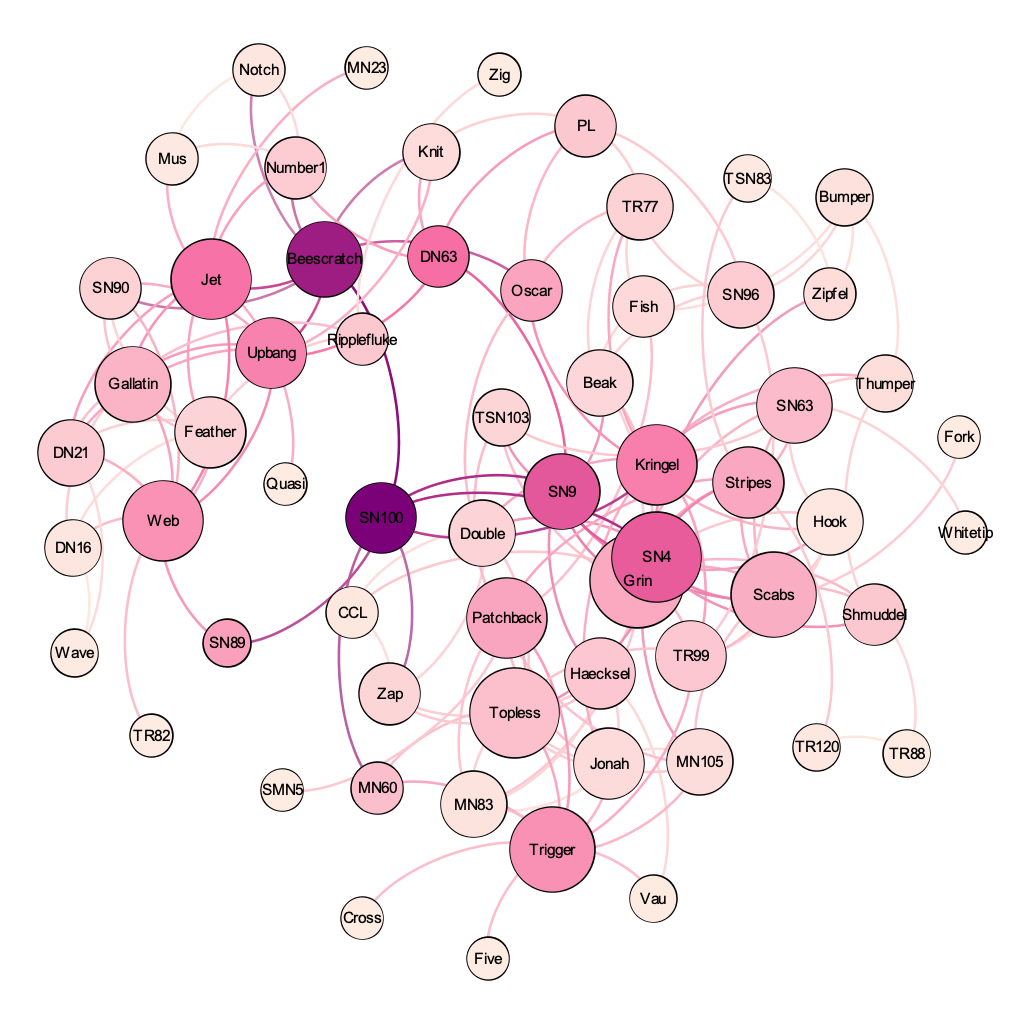